# WQD7004_GroupProject

## Group No.: 10

## Group Members

- LINGYU MENG (S2131391)
- HUIJUN LIU (S2142285)
- ZUOGE CHEN (S2125783)
- KELVIIN RAJJ KARUPAYA (S2151665)
- RUIXUE ZHANG (S2142119)

## Dataset

- Title: German Credit Risk
- Year: 2020
- Content: This dataset classifies people described by a set of attributes as good or bad credit risks.
- Source: https://www.kaggle.com/datasets/kabure/german-credit-data-with-risk
- Title: Sanction Loan
- Year: 2021
- Content: This dataset contains features related to predict the loan amount.
- Source: https://www.kaggle.com/datasets/zyper26/sanction-loan

# 1 Introduction

In the German Credit Risk dataset, each entry represents a person who takes a credit by a bank. Each person is classified as good or bad credit risks according to the set of attributes.

In the Sanction Loan dataset, we need predict the loan amount that can be sanctioned to customers who have applied for a home loan using the features provided.

## 1.1 Project Objective

- To predict the credit risk level of applicants.
- To predict the loan amount.

## 1.2 Project Question

- Which model performs best on predicting the credit risk level of applicants? (classification)
- Which model performs best on predicting the loan amount? (regression)

# 2 Data Pre-processing

## 2.1 German Credit Risk dataset

### 2.1.1 Data Understanding

### Import libraries

```r
library(dplyr)
library(readr)
library(VIM)
library(missForest)
library(Hmisc)
library(caret)
library(ggplot2)
library(e1071)
library(klaR)
library(nnet)
library(Metrics)
library(rpart)
library(rpart.plot)
library(tidyverse)
library(skimr)
library(caret)
library(pROC)
library(DataExplorer)
library(mice)
```

### Read data

```r
df = read.csv('german_credit_data.csv', stringsAsFactors = T)
#df = read.csv(file.choose(), stringsAsFactors = T)
#Delete the 1st column which is used for indexing.
df=df[,-1]
head(df)
```

```
##   Age    Sex Job Housing Saving.accounts Checking.account Credit.amount
## 1  67   male   2     own            <NA>           little          1169
## 2  22 female   2     own          little         moderate          5951
## 3  49   male   1     own          little             <NA>          2096
## 4  45   male   2    free          little           little          7882
## 5  53   male   2    free          little           little          4870
## 6  35   male   1    free            <NA>             <NA>          9055
##   Duration             Purpose Risk
## 1        6            radio/TV good
## 2       48            radio/TV  bad
## 3       12           education good
## 4       42 furniture/equipment good
## 5       24                 car  bad
## 6       36           education good
```

### See the structure of dataset

```r
str(df)
```

```
## 'data.frame':    1000 obs. of  10 variables:
##  $ Age             : int  67 22 49 45 53 35 53 35 61 28 ...
##  $ Sex             : Factor w/ 2 levels "female","male": 2 1 2 2 2 2 2 2 2 2 ...
##  $ Job             : int  2 2 1 2 2 1 2 3 1 3 ...
##  $ Housing         : Factor w/ 3 levels "free","own","rent": 2 2 2 1 1 1 2 3 2 2 ...
##  $ Saving.accounts : Factor w/ 4 levels "little","moderate",..: NA 1 1 1 1 NA 3 1 4 1 ...
##  $ Checking.account: Factor w/ 3 levels "little","moderate",..: 1 2 NA 1 1 NA NA 2 NA 2 ...
##  $ Credit.amount   : int  1169 5951 2096 7882 4870 9055 2835 6948 3059 5234 ...
##  $ Duration        : int  6 48 12 42 24 36 24 36 12 30 ...
##  $ Purpose         : Factor w/ 8 levels "business","car",..: 6 6 4 5 2 4 5 2 6 2 ...
##  $ Risk            : Factor w/ 2 levels "bad","good": 2 1 2 2 1 2 2 2 2 1 ...
```

## 2.1.2 Handle missing data

### Check missing values

```r
print(paste('Complete obs.:',sum(complete.cases(df))))
```

```
## [1] "Complete obs.: 522"
```

- Distribution of NAs (by column):

```r
colSums(is.na(df))
```

```
##              Age              Sex              Job          Housing
##                0                0                0                0
##  Saving.accounts Checking.account    Credit.amount         Duration
##              183              394                0                0
##          Purpose             Risk
##                0                0
```

- Check if any missing value is “” type

```r
colSums(df=="")
```

```
##              Age              Sex              Job          Housing
##                0                0                0                0
##  Saving.accounts Checking.account    Credit.amount         Duration
##               NA               NA                0                0
##          Purpose             Risk
##                0                0
```

### Visualisation of missing part

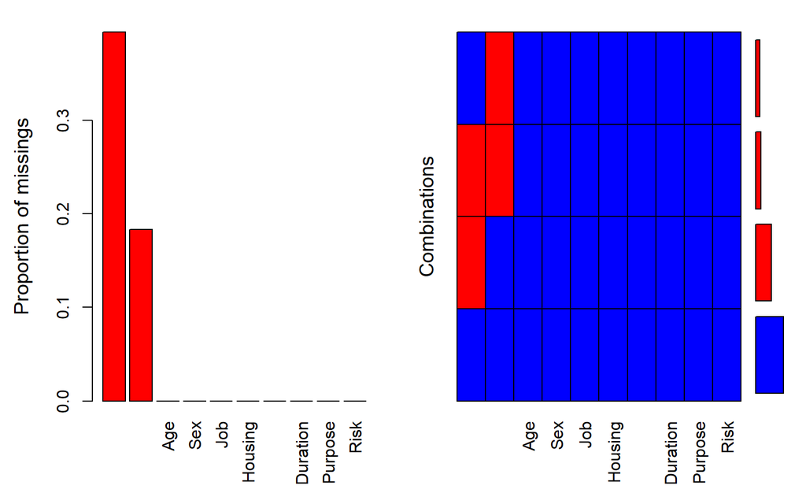

```
##
##  Variables sorted by number of missings:
##          Variable Count
##  Checking.account 0.394
##   Saving.accounts 0.183
##               Age 0.000
##               Sex 0.000
##               Job 0.000
##           Housing 0.000
##     Credit.amount 0.000
##          Duration 0.000
##           Purpose 0.000
##              Risk 0.000
```

```r
aggr(df,labels=names(df),col=c('blue','red'),
     numbrs=T,sortVars=T)
```

As shown above, Saving.accounts & Check.account contain missing values, and red color presents missing part.

### Impute NAs

**missForest** is used to impute missing values particularly in the case of mixed-type data. It can be used to impute **continuous and/or categorical** data including complex interactions and nonlinear relations. It yields an out-of-bag (OOB) imputation error estimate. Moreover, it can be run parallel to save computation time.

```r
df.mis <- df[!complete.cases(df),]
df.train <- df[complete.cases(df),]
set.seed(42)
df.imp <- missForest(xmis = df.mis, xtrue = df.train, maxiter = 10, ntree = 200)
message('Out of Bag error: ', df.imp$OOBerror)
```

```
## Out of Bag error: 00.122854452515469
```

**Save imputation result**

```r
df.nomis <- df
df.nomis[!complete.cases(df.nomis),] <- df.imp$ximp
```

**Saving.account values distribution after imputation:**

```r
table(df.nomis$Saving.accounts)
```

```
##
##     little   moderate quite rich       rich
##        731        116         92         61
```

**Checking.account values distribution after imputation:**

```r
table(df.nomis$Checking.account)
```

```
##
##   little moderate     rich
##      364      482      154
```

- Save cleaned dataset

```r
write.csv(df.nomis,file = 'german_credit_data_rmna.csv',row.names=F)
```

- Summary dataset

```r
summary(df.nomis)
```

```
##       Age            Sex           Job        Housing      Saving.accounts
##  Min.   :19.00   female:310   Min.   :0.000   free:108   little    :731
##  1st Qu.:27.00   male  :690   1st Qu.:2.000   own :713   moderate  :116
##  Median :33.00                Median :2.000   rent:179   quite rich: 92
##  Mean   :35.55                Mean   :1.904              rich      : 61
##  3rd Qu.:42.00                3rd Qu.:2.000
##  Max.   :75.00                Max.   :3.000
##
##  Checking.account Credit.amount      Duration                   Purpose
##  little  :364     Min.   :  250   Min.   : 4.0   car                :337
##  moderate:482     1st Qu.: 1366   1st Qu.:12.0   radio/TV           :280
##  rich    :154     Median : 2320   Median :18.0   furniture/equipment:181
##                   Mean   : 3271   Mean   :20.9   business           : 97
##                   3rd Qu.: 3972   3rd Qu.:24.0   education          : 59
##                   Max.   :18424   Max.   :72.0   repairs            : 22
##                                                  (Other)            : 24
##    Risk
##  bad :300
##  good:700
##
##
##
##
##
```

### Descriptions of cleaned dataset

- Age: (quantitative, in years)
- Sex: (dichotomous: female, male)
- Job: (ordinal: 0 - unskilled and non-resident, 1 - unskilled and resident, 2 - skilled, 3 - highly skilled)
- Housing: (nominal: own, rent, or free)
- Saving.accounts: (ordinal: little, moderate, quite rich, rich) - Status of existing saving account.
- Checking.account: (ordinal: little, moderate, rich) - Status of existing checking account.
- Credit.amount: (quantitative, in D-mark) The maximum amount that the bank is committed to lend.
- Duration: (quantitative, in month) The specified time to pay the credit.
- Purpose: (nominal: car, furniture/equipment, radio/TV, domestic appliances, repairs, education, business, vacation/others) - Reasons to get a loan.
- Risk: (dichotomous : good, bad)

## 2.2 Sanction Loan dataset

### 2.2.1 Data Understanding

### Read data

```r
data = read.csv('train.csv', stringsAsFactors = T)
#data = read.csv(file.choose(), stringsAsFactors = T)
#select needed vars for regression model.
data=subset(data, select=c(Age, Income..USD., Loan.Amount.Request..USD.,
                           Current.Loan.Expenses..USD., Credit.Score,
                           Property.Price, Loan.Sanction.Amount..USD., Type.of.Employment))
#rename vars
names(data) <- c('Age','Income','Loan.Amount.Request','Current.Loan.Expenses','Credit.Score','Property.Price','Loan.Sanction.Amount','Employment.Type')
head(data)
```

```
##   Age  Income Loan.Amount.Request Current.Loan.Expenses Credit.Score
## 1  56 1933.05            72809.58                241.08       809.44
## 2  32 4952.91            46837.47                495.81       780.40
## 3  65  988.19            45593.04                171.95       833.15
## 4  65      NA            80057.92                298.54       832.70
## 5  31 2614.77           113858.89                491.41       745.55
## 6  60 1234.92            34434.72                181.48       684.12
##   Property.Price Loan.Sanction.Amount       Employment.Type
## 1      119933.46             54607.18           Sales staff
## 2       54791.00             37469.98
## 3       72440.58             36474.43
## 4      121441.51             56040.54
## 5      208567.91             74008.28 High skill tech staff
## 6       43146.82             22382.57           Secretaries
```

### See the structure of dataset

```r
str(data)
```

```
## 'data.frame':    30000 obs. of  8 variables:
##  $ Age                  : int  56 32 65 65 31 60 43 45 38 18 ...
##  $ Income               : num  1933 4953 988 NA 2615 ...
##  $ Loan.Amount.Request  : num  72810 46837 45593 80058 113859 ...
##  $ Current.Loan.Expenses: num  241 496 172 299 491 ...
##  $ Credit.Score         : num  809 780 833 833 746 ...
##  $ Property.Price       : num  119933 54791 72441 121442 208568 ...
##  $ Loan.Sanction.Amount : num  54607 37470 36474 56041 74008 ...
##  $ Employment.Type      : Factor w/ 19 levels "","Accountants",..: 16 1 1 1 7 17 10 12 4 10 ...
```

## 2.2.2 Handle missing data

### Check missing values

```r
print(paste('Complete obs.:',sum(complete.cases(data))))
```

```
## [1] "Complete obs.: 23820"
```

- Distribution of NAs (by column):

```r
colSums(is.na(data))
```

```
##                   Age                Income   Loan.Amount.Request
##                     0                  4576                     0
## Current.Loan.Expenses          Credit.Score        Property.Price
##                   172                  1703                     0
##  Loan.Sanction.Amount       Employment.Type
##                   340                     0
```

- Check if any missing value is “” type

```r
colSums(data=="")
```

```
##                   Age                Income   Loan.Amount.Request
##                     0                    NA                     0
## Current.Loan.Expenses          Credit.Score        Property.Price
##                    NA                    NA                     0
##  Loan.Sanction.Amount       Employment.Type
##                    NA                  7270
```

### Visualisation of missing part

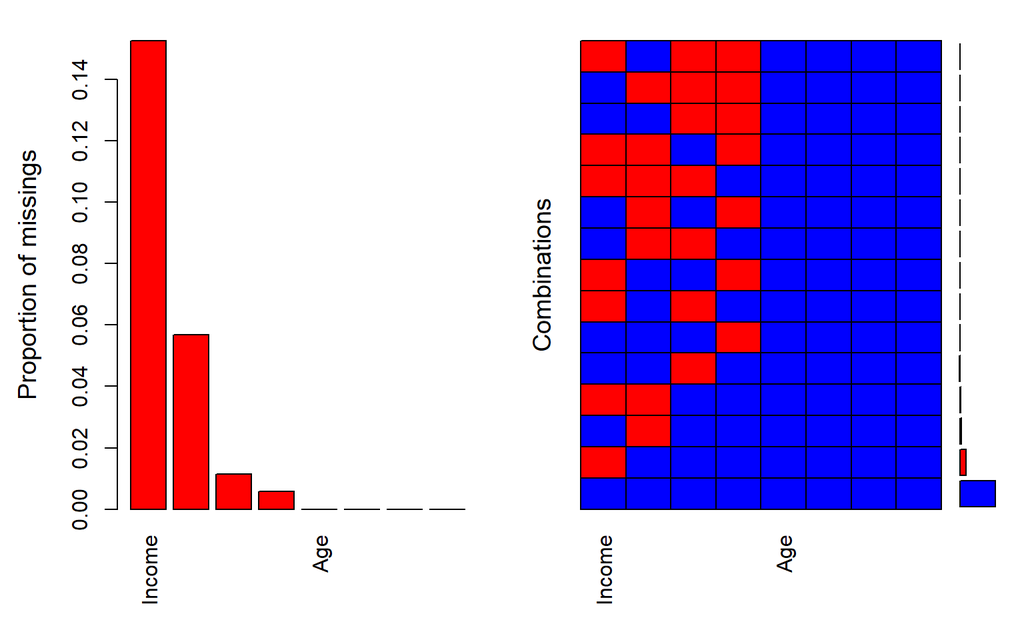

```
##
##  Variables sorted by number of missings:
##               Variable       Count
##                 Income 0.152533333
##           Credit.Score 0.056766667
##   Loan.Sanction.Amount 0.011333333
##  Current.Loan.Expenses 0.005733333
##                    Age 0.000000000
##    Loan.Amount.Request 0.000000000
##         Property.Price 0.000000000
##        Employment.Type 0.000000000
```

```r
aggr(data,labels=names(data),col=c('blue','red'),
     numbrs=T,sortVars=T)
```

As shown above, 4 columns contain missing values, and red color presents missing part.

### impute NAs and solve outliers

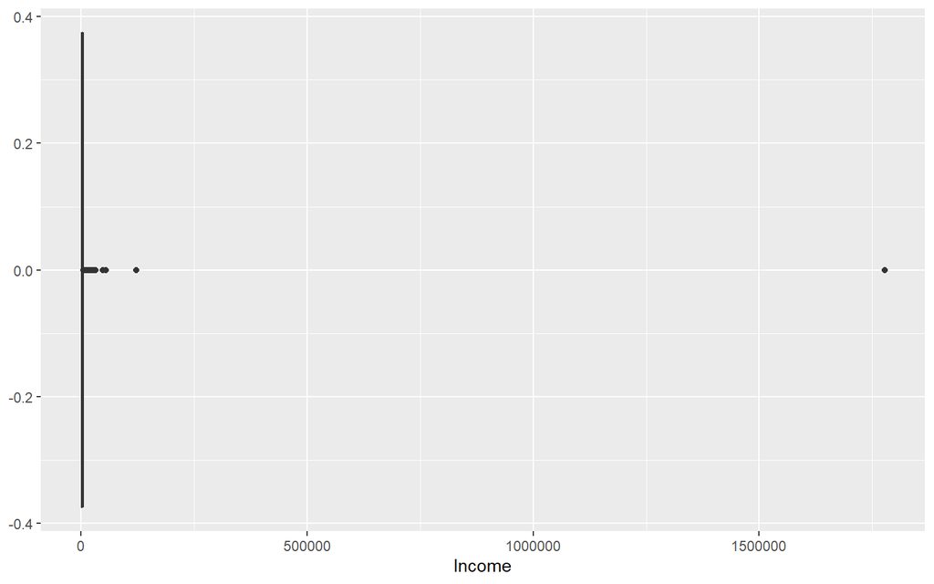

```r
# use group median income of employment type to impute income
new <- ave(data$Income, list(data$Employment.Type), FUN=function(x) median(x, na.rm = TRUE))
# smooth anomaly obs
ggplot(data)+
  geom_boxplot(aes(x=Income))
```

```r
data$Income[is.na(data$Income)] <- new[is.na(data$Income)]
data[data['Income']>120000,'Income']<- median(data[data$Employment.Type==data[data['Income']>120000,'Employment.Type'],'Income'])
```

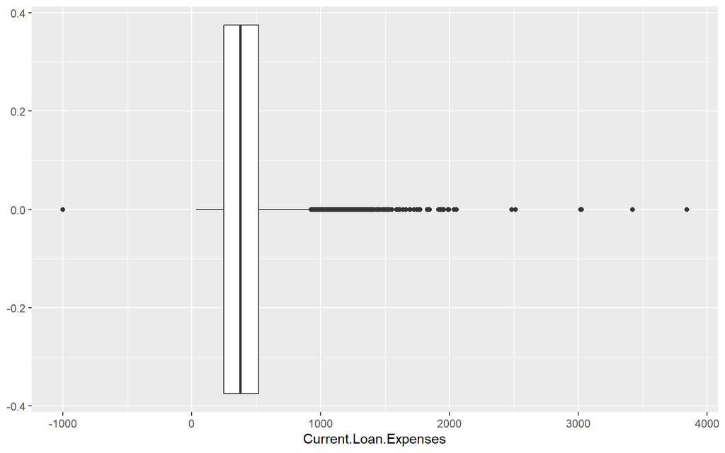

```r
data$Current.Loan.Expenses[is.na(data$Current.Loan.Expenses)] <- median(data$Current.Loan.Expenses, na.rm=TRUE)
ggplot(data)+
  geom_boxplot(aes(x=Current.Loan.Expenses))
```

```r
data[data$Current.Loan.Expenses<0,]$Current.Loan.Expenses <- median(data$Current.Loan.Expenses, na.rm=TRUE)
```

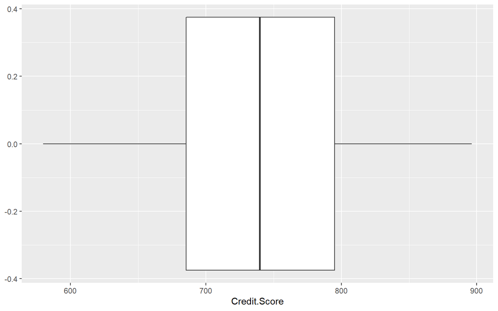

```r
data$Credit.Score[is.na(data$Credit.Score)] <- mean(data$Credit.Score, na.rm=TRUE)
ggplot(data)+
  geom_boxplot(aes(x=Credit.Score))
```

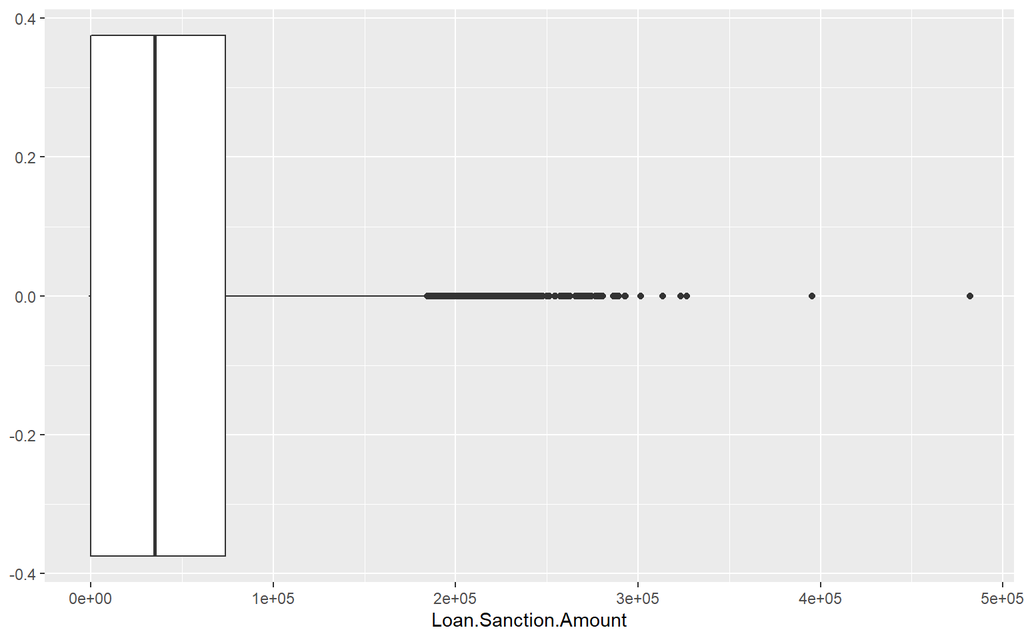

```r
data$Loan.Sanction.Amount[is.na(data$Loan.Sanction.Amount)] <-
median(data$Loan.Sanction.Amount, na.rm=TRUE)
ggplot(data)+
  geom_boxplot(aes(x=Loan.Sanction.Amount))
```

```r
data=subset(data,select = -c(Employment.Type))
```

- Save cleaned dataset

```r
write.csv(data,file = 'train_cleaned.csv',row.names=F)
```

- Summary dataset

```r
summary(data)
```

```
##       Age            Income        Loan.Amount.Request Current.Loan.Expenses
##  Min.   :18.00   Min.   :  377.7   Min.   :  6048      Min.   :  33.76
##  1st Qu.:25.00   1st Qu.: 1738.8   1st Qu.: 41178      1st Qu.: 252.14
##  Median :40.00   Median : 2165.9   Median : 75128      Median : 375.20
##  Mean   :40.09   Mean   : 2510.5   Mean   : 88826      Mean   : 408.90
##  3rd Qu.:55.00   3rd Qu.: 2959.3   3rd Qu.:119965      3rd Qu.: 520.10
##  Max.   :65.00   Max.   :54653.8   Max.   :621498      Max.   :3840.88
##   Credit.Score   Property.Price    Loan.Sanction.Amount
##  Min.   :580.0   Min.   :   -999   Min.   :  -999
##  1st Qu.:685.4   1st Qu.:  60572   1st Qu.:     0
##  Median :739.9   Median : 109994   Median : 35209
##  Mean   :739.9   Mean   : 131760   Mean   : 47508
##  3rd Qu.:795.1   3rd Qu.: 178881   3rd Qu.: 73764
##  Max.   :896.3   Max.   :1077967   Max.   :481907
```

# 3 Exploratory Data Analysis

## 3.1 show the relationship between the duration of credit and the credit amount

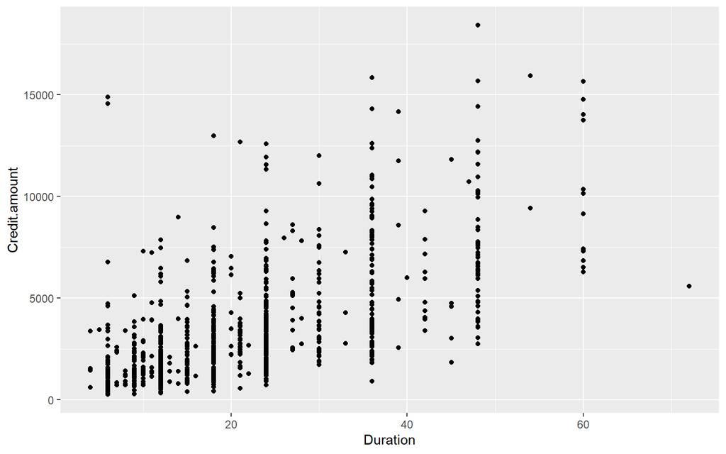

```r
Dur_Cred_Plot<-ggplot(df.nomis, aes(x=Duration, y=Credit.amount))+geom_point()
Dur_Cred_Plot
```

## 3.2 show the relationship between the sex and the credit amount

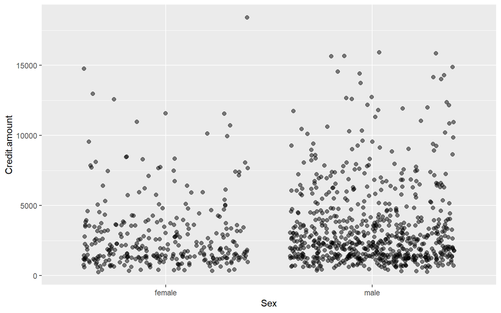

```r
Sex_Cred_Plot<-ggplot(df.nomis,aes(x=Sex, y=Credit.amount))+geom_jitter(size=2, alpha=0.5)
Sex_Cred_Plot
```

## 3.3 analyse the relationship between duration of credit and age

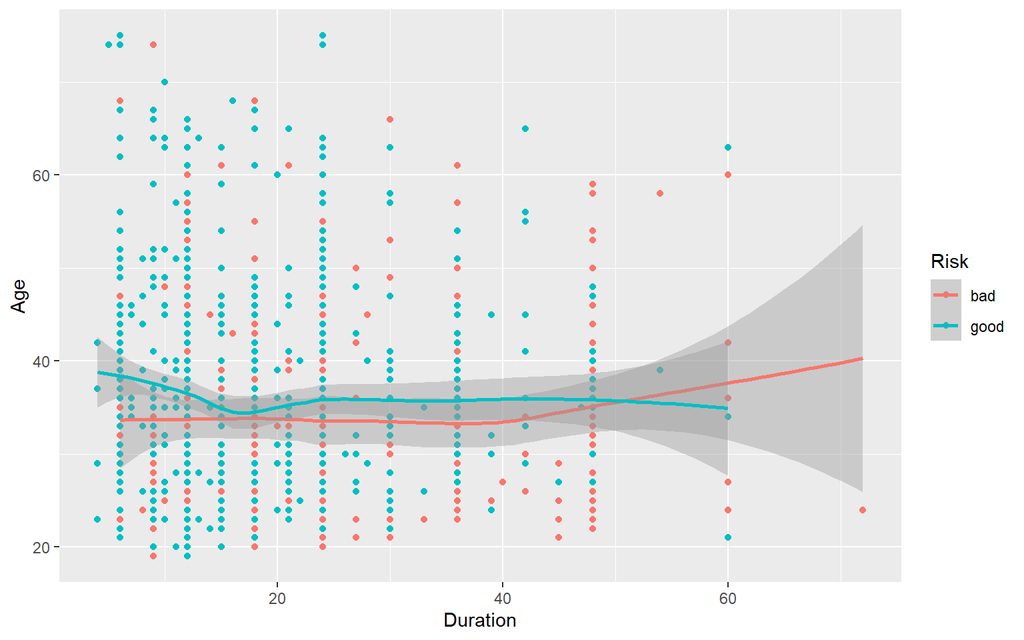

```r
Dur_Age_Plot<-ggplot(df.nomis,aes(x=Duration, y=Age, color=Risk))+geom_point()+geom_smooth()
Dur_Age_Plot
```

## 3.4 display points in scatter plot for bad and good loans

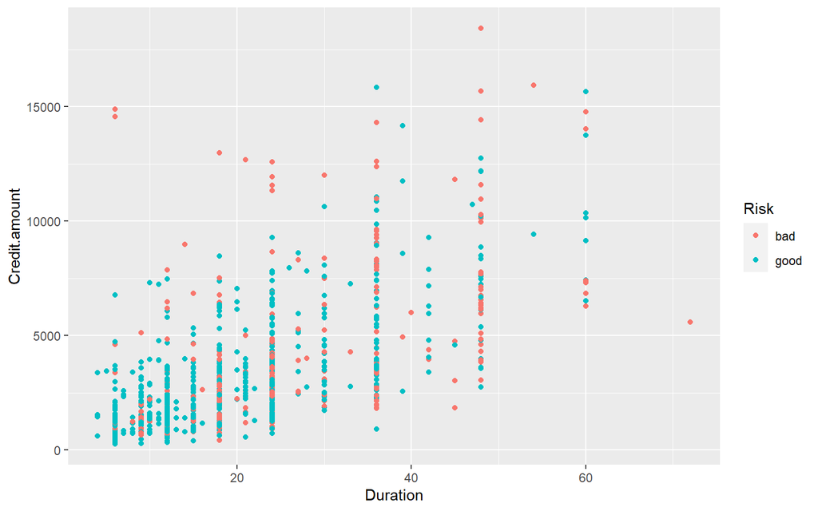

```r
Dur_Cred_Risk_Plot<-ggplot(df.nomis,aes(x=Duration,y=Credit.amount))+geom_point(aes(color=Risk))
Dur_Cred_Risk_Plot
```

## 3.5 use faceting to split entire graph into 2 separate panels for each, good and bads loans

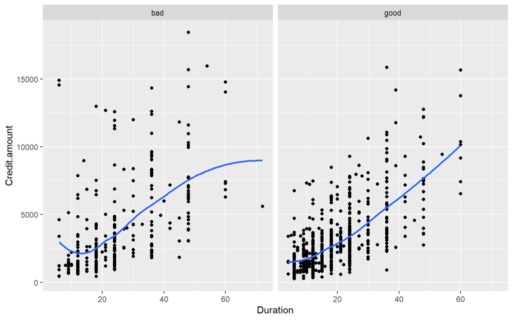

```r
Dur_Cred_Risk_facetPlot<-ggplot(df.nomis,aes(x=Duration, y=Credit.amount))+geom_point()+geom_smooth(se=F)+
  facet_grid(.~Risk)
Dur_Cred_Risk_facetPlot
```

## 3.6 check how the Job variable impacts the credit

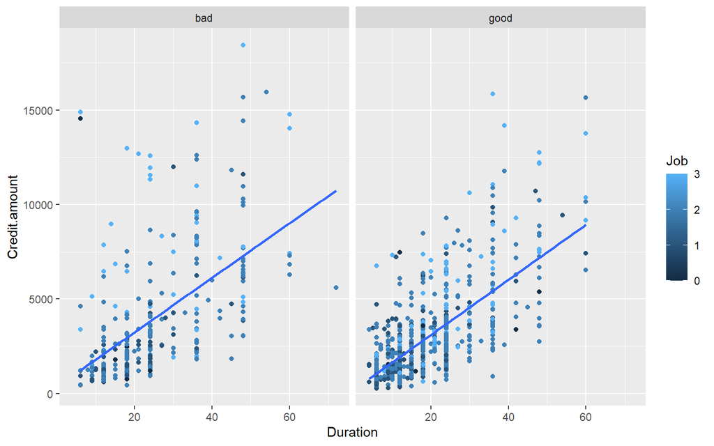

```r
Dur_Cred_Risk_Job_Plot<-ggplot(df.nomis,aes(x=Duration, y=Credit.amount, color=Job))+geom_point()+geom_smooth(se=F, method="lm")+
  facet_grid(.~Risk)
Dur_Cred_Risk_Job_Plot
```

## 3.7 facet to split the graph into the 4 type job variables

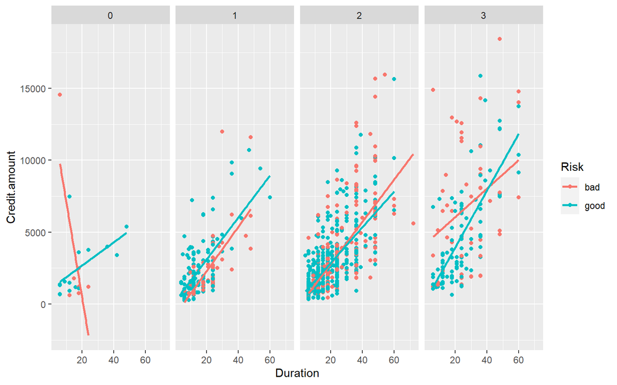

```r
Dur_Cred_Risk_Job_facetPlot<-ggplot(df.nomis,aes(x=Duration, y=Credit.amount, color=Risk))+geom_point()+geom_smooth(se=F, method="lm")+
  facet_grid(.~Job)
Dur_Cred_Risk_Job_facetPlot
```

## 3.8 show relationship between the savings account and credit amount

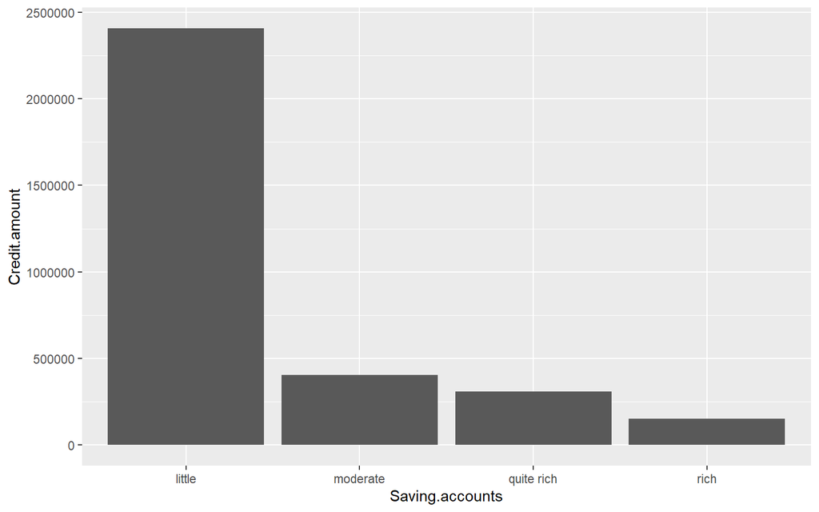

```r
Sav_Cred_Plot<-ggplot(df.nomis,aes(x=Saving.accounts, y=Credit.amount))+geom_bar(stat="identity")
Sav_Cred_Plot
```

## 3.9 show the good and bad loans in each savings account category

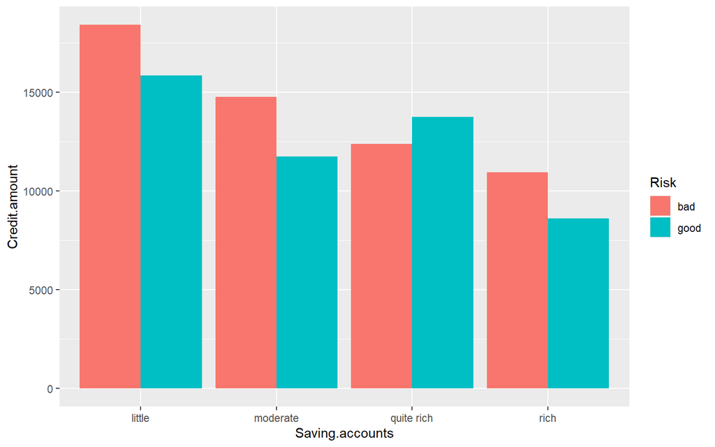

```r
Sav_Cred_Risk_Plot<-ggplot(df.nomis,aes(x=Saving.accounts, y=Credit.amount, fill=Risk))+geom_bar(stat="identity", position=position_dodge())
Sav_Cred_Risk_Plot
```

## 3.10 analyse the good and bad loans in the relationship between duration of credit and credit amount using the housing variable

```r
Dur_Cred_House_Risk<-ggplot(df.nomis,aes(x=Duration, y=Credit.amount))+geom_point()+geom_smooth()+
  facet_grid(Housing~Risk)
```

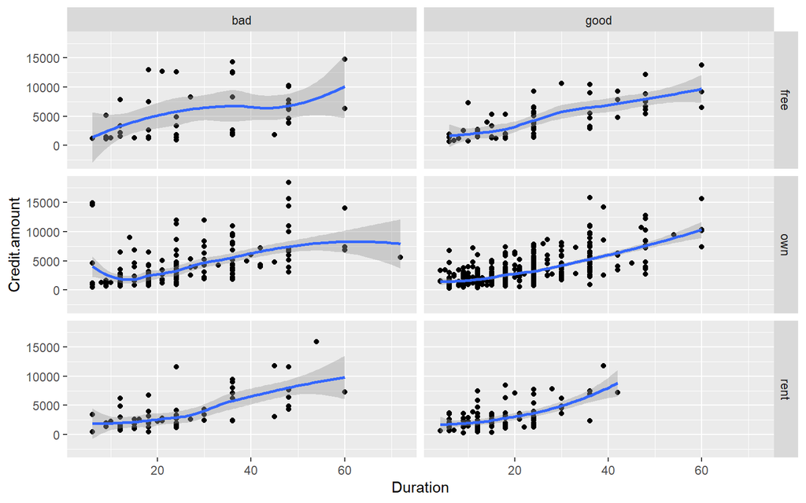

```r
Dur_Cred_House_Risk
```

# 4 Modeling

## 4.1 Regression Model predict loan sanction amount (regression)

```r
skim(data)
```

Data summary

| Name | data |
| --- | --- |
| Number of rows | 30000 |
| Number of columns | 7 |
| _______________________ |  |
| Column type frequency: |  |
| numeric | 7 |
| ________________________ |  |
| Group variables | None |

**Variable type: numeric**

| skim_variable | n_missing | complete_rate | mean | sd | p0 | p25 | p50 | p75 | p100 | hist |
| --- | --- | --- | --- | --- | --- | --- | --- | --- | --- | --- |
| Age | 0 | 1 | 40.09 | 16.05 | 18.00 | 25.00 | 40.00 | 55.00 | 65.00 | ▇▅▅▃▆ |
| Income | 0 | 1 | 2510.54 | 1428.64 | 377.70 | 1738.83 | 2165.87 | 2959.31 | 54653.75 | ▇▁▁▁▁ |
| Loan.Amount.Request | 0 | 1 | 88826.33 | 59536.95 | 6048.24 | 41177.76 | 75128.07 | 119964.60 | 621497.82 | ▇▂▁▁▁ |
| Current.Loan.Expenses | 0 | 1 | 408.90 | 216.50 | 33.76 | 252.14 | 375.20 | 520.10 | 3840.88 | ▇▁▁▁▁ |
| Credit.Score | 0 | 1 | 739.89 | 70.09 | 580.00 | 685.42 | 739.89 | 795.14 | 896.26 | ▂▆▇▆▃ |
| Property.Price | 0 | 1 | 131759.68 | 93549.55 | -999.00 | 60572.16 | 109993.61 | 178880.72 | 1077966.73 | ▇▂▁▁▁ |
| Loan.Sanction.Amount | 0 | 1 | 47508.36 | 47965.19 | -999.00 | 0.00 | 35209.40 | 73763.53 | 481907.32 | ▇▂▁▁▁ |

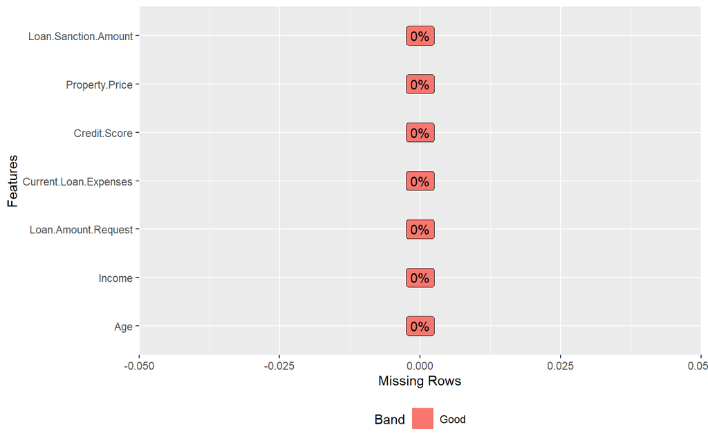

```r
# Check the missing data
plot_missing(data)
```

```r
class(data)
```

```
## [1] "data.frame"
```

```r
head(data)
```

```
##   Age  Income Loan.Amount.Request Current.Loan.Expenses Credit.Score
## 1  56 1933.05            72809.58                241.08       809.44
## 2  32 4952.91            46837.47                495.81       780.40
## 3  65  988.19            45593.04                171.95       833.15
## 4  65 2123.95            80057.92                298.54       832.70
## 5  31 2614.77           113858.89                491.41       745.55
## 6  60 1234.92            34434.72                181.48       684.12
##   Property.Price Loan.Sanction.Amount
## 1      119933.46             54607.18
## 2       54791.00             37469.98
## 3       72440.58             36474.43
## 4      121441.51             56040.54
## 5      208567.91             74008.28
## 6       43146.82             22382.57
```

```r
# feature engineering
# Train/Test split for Regression
set.seed(42)
train1 <-createDataPartition(y=data$Loan.Sanction.Amount,p=0.7,list=FALSE)

train <- data[train1, ]

test <- data[-train1, ]
```

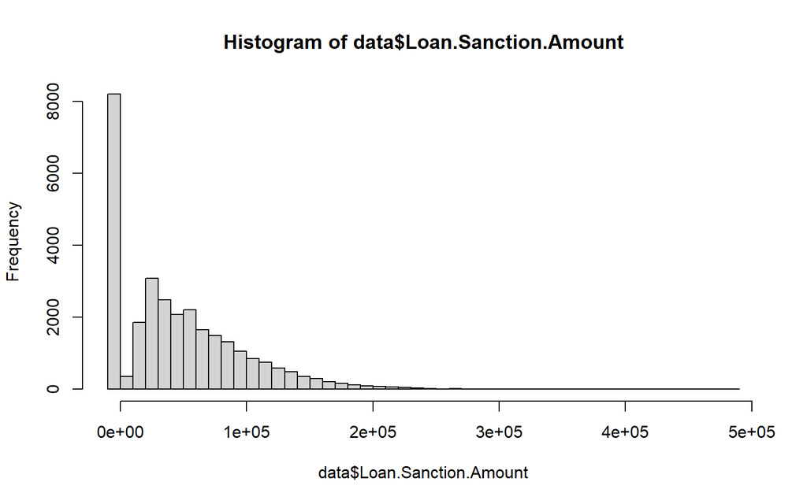

```r
hist(data$Loan.Sanction.Amount,breaks=50)
```

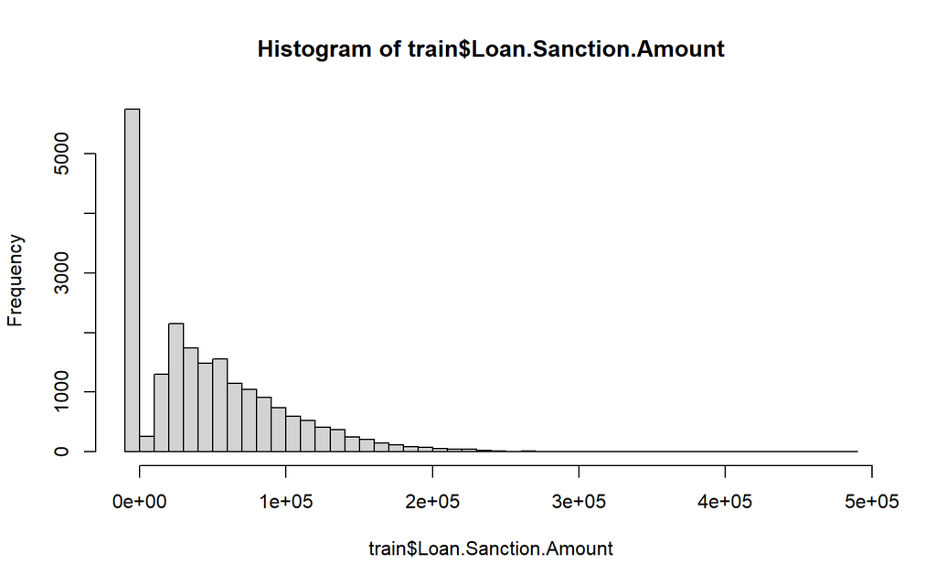

```r
# Split dependent variable distribution
hist(train$Loan.Sanction.Amount,breaks=50)
```

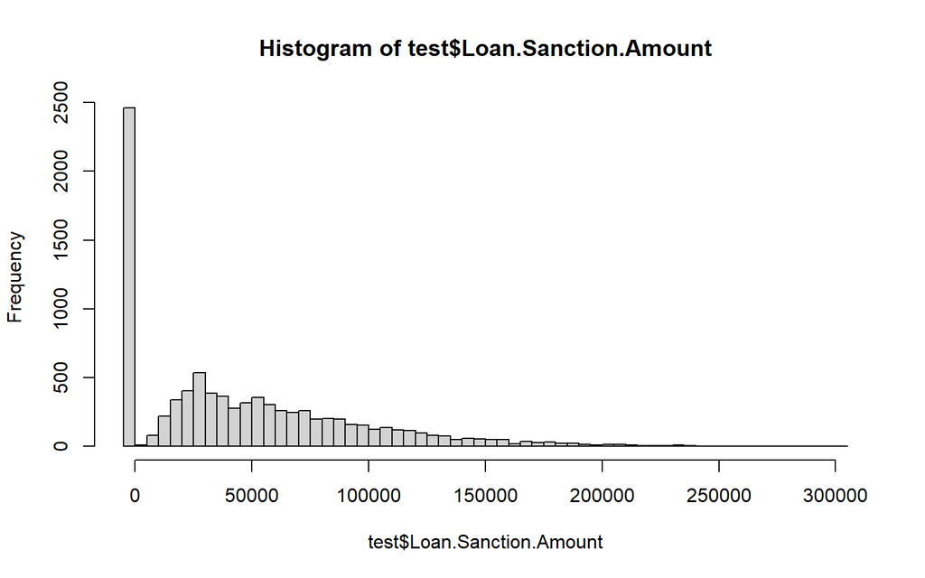

```r
hist(test$Loan.Sanction.Amount,breaks=50)
```

```r
# fold cross validation
train_control <- trainControl(method="cv", number=10)
```

### 4.1.1 simple linear regression model (r2 = 0.5201)

```r
# the correlation between all vars
cor(data)
```

```
##                                Age      Income Loan.Amount.Request
## Age                    1.000000000 -0.04401547         -0.01045006
## Income                -0.044015468  1.00000000          0.33328928
## Loan.Amount.Request   -0.010450063  0.33328928          1.00000000
## Current.Loan.Expenses -0.027798368  0.39371501          0.75811810
## Credit.Score           0.125900318  0.09194725          0.17332929
## Property.Price        -0.009819131  0.31816122          0.94834970
## Loan.Sanction.Amount   0.008176474  0.23238303          0.72118116
##                       Current.Loan.Expenses Credit.Score Property.Price
## Age                             -0.02779837   0.12590032   -0.009819131
## Income                           0.39371501   0.09194725    0.318161216
## Loan.Amount.Request              0.75811810   0.17332929    0.948349703
## Current.Loan.Expenses            1.00000000   0.11950694    0.719853606
## Credit.Score                     0.11950694   1.00000000    0.166003667
## Property.Price                   0.71985361   0.16600367    1.000000000
## Loan.Sanction.Amount             0.54058003   0.35744876    0.682010166
##                       Loan.Sanction.Amount
## Age                            0.008176474
## Income                         0.232383032
## Loan.Amount.Request            0.721181161
## Current.Loan.Expenses          0.540580031
## Credit.Score                   0.357448760
## Property.Price                 0.682010166
## Loan.Sanction.Amount           1.000000000
```

```r
# the correlation between target and each feature
data_cor <- cor(data[ , colnames(data) != "Loan.Sanction.Amount"],
                data$Loan.Sanction.Amount)
data_cor
```

```
##                              [,1]
## Age                   0.008176474
## Income                0.232383032
## Loan.Amount.Request   0.721181161
## Current.Loan.Expenses 0.540580031
## Credit.Score          0.357448760
## Property.Price        0.682010166
```

```r
fit <- lm(Loan.Sanction.Amount ~ Loan.Amount.Request,data = data)
summary(fit)
```

```
##
## Call:
## lm(formula = Loan.Sanction.Amount ~ Loan.Amount.Request, data = data)
##
## Residuals:
##     Min      1Q  Median      3Q     Max
## -356996  -11276    9952   17510  136017
##
## Coefficients:
##                       Estimate Std. Error t value Pr(>|t|)
## (Intercept)         -4.101e+03  3.446e+02   -11.9   <2e-16 ***
## Loan.Amount.Request  5.810e-01  3.222e-03   180.3   <2e-16 ***
## ---
## Signif. codes:  0 '***' 0.001 '**' 0.01 '*' 0.05 '.' 0.1 ' ' 1
##
## Residual standard error: 33230 on 29998 degrees of freedom
## Multiple R-squared:  0.5201, Adjusted R-squared:  0.5201
## F-statistic: 3.251e+04 on 1 and 29998 DF,  p-value: < 2.2e-16
```

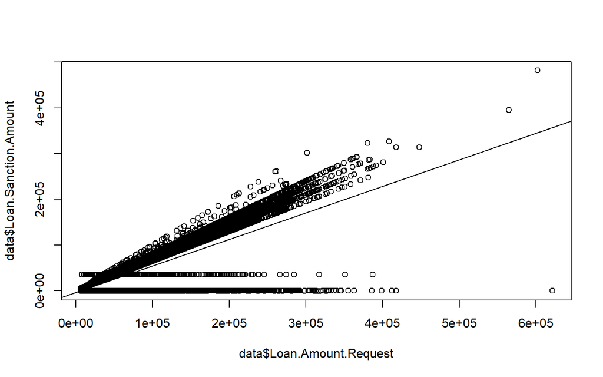

```r
plot(data$Loan.Amount.Request,data$Loan.Sanction.Amount)
abline(fit)
```

### 4.1.2 multiple linear regression model (r2 = 0.5764)

```r
fit2 <- lm(Loan.Sanction.Amount ~ Age+Income+Loan.Amount.Request+Current.Loan.Expenses+Credit.Score+Property.Price,data = data)
summary(fit2)
```

```
##
## Call:
## lm(formula = Loan.Sanction.Amount ~ Age + Income + Loan.Amount.Request +
##     Current.Loan.Expenses + Credit.Score + Property.Price, data = data)
##
## Residuals:
##     Min      1Q  Median      3Q     Max
## -336285   -7528    8066   17987  137929
##
## Coefficients:
##                         Estimate Std. Error t value Pr(>|t|)
## (Intercept)           -1.207e+05  1.945e+03 -62.079  < 2e-16 ***
## Age                   -4.797e+01  1.135e+01  -4.228 2.36e-05 ***
## Income                -6.252e-01  1.377e-01  -4.539 5.67e-06 ***
## Loan.Amount.Request    5.706e-01  1.018e-02  56.080  < 2e-16 ***
## Current.Loan.Expenses -4.942e-01  1.312e+00  -0.377   0.7065
## Credit.Score           1.659e+02  2.637e+00  62.917  < 2e-16 ***
## Property.Price        -1.158e-02  6.074e-03  -1.907   0.0565 .
## ---
## Signif. codes:  0 '***' 0.001 '**' 0.01 '*' 0.05 '.' 0.1 ' ' 1
##
## Residual standard error: 31220 on 29993 degrees of freedom
## Multiple R-squared:  0.5764, Adjusted R-squared:  0.5763
## F-statistic:  6802 on 6 and 29993 DF,  p-value: < 2.2e-16
```

```r
anova(fit,fit2)
```

```
## Analysis of Variance Table
##
## Model 1: Loan.Sanction.Amount ~ Loan.Amount.Request
## Model 2: Loan.Sanction.Amount ~ Age + Income + Loan.Amount.Request + Current.Loan.Expenses +
##     Credit.Score + Property.Price
##   Res.Df        RSS Df Sum of Sq      F    Pr(>F)
## 1  29998 3.3121e+13
## 2  29993 2.9235e+13  5 3.886e+12 797.35 < 2.2e-16 ***
## ---
## Signif. codes:  0 '***' 0.001 '**' 0.01 '*' 0.05 '.' 0.1 ' ' 1
```

```r
# ridge regression (r2 = 0.5839)
set.seed(42)
model_ridge <- train(Loan.Sanction.Amount ~ Age+Income+Loan.Amount.Request+Current.Loan.Expenses+Credit.Score+Property.Price, data= train, trControl=train_control,method="ridge", metric="RMSE")
model_ridge
```

```
## Ridge Regression
##
## 21001 samples
##     6 predictor
##
## No pre-processing
## Resampling: Cross-Validated (10 fold)
## Summary of sample sizes: 18902, 18899, 18901, 18901, 18900, 18902, ...
## Resampling results across tuning parameters:
##
##   lambda  RMSE      Rsquared   MAE
##   0e+00   31363.16  0.5722034  21851.93
##   1e-04   31363.15  0.5722037  21852.06
##   1e-01   31680.70  0.5646301  21874.54
##
## RMSE was used to select the optimal model using the smallest value.
## The final value used for the model was lambda = 1e-04.
```

```r
# Least Angle Regression (r2 = 0.5839)
set.seed(42)
model_lars <- train(Loan.Sanction.Amount ~ Age+Income+Loan.Amount.Request+Current.Loan.Expenses+Credit.Score+Property.Price, data= train, trControl=train_control,method="lars", metric="RMSE")
model_lars
```

```
## Least Angle Regression
##
## 21001 samples
##     6 predictor
##
## No pre-processing
## Resampling: Cross-Validated (10 fold)
## Summary of sample sizes: 18902, 18899, 18901, 18901, 18900, 18902, ...
## Resampling results across tuning parameters:
##
##   fraction  RMSE      Rsquared   MAE
##   0.050     46129.19  0.5159886  36451.24
##   0.525     33931.76  0.5500401  24989.65
##   1.000     31363.16  0.5722034  21851.93
##
## RMSE was used to select the optimal model using the smallest value.
## The final value used for the model was fraction = 1.
```

```r
# lasso regression (r2 = 0.5763)
x <- data.matrix(subset(data,select = -c(Loan.Sanction.Amount)))
y <- data$Loan.Sanction.Amount
library(glmnet)
#perform k-fold cross-validation to find optimal lambda value
cv_model <- cv.glmnet(x, y, alpha = 1)

#find optimal lambda value that minimizes test MSE
best_lambda <- cv_model$lambda.min
best_lambda
```

```
## [1] 108.1217
```

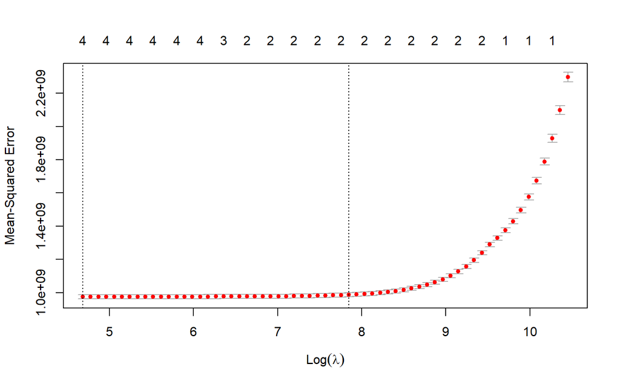

```r
plot(cv_model)
```

```r
best_model <- glmnet(x, y, alpha = 1, lambda = best_lambda)
coef(best_model)
```

```
## 7 x 1 sparse Matrix of class "dgCMatrix"
##                                  s0
## (Intercept)           -1.199608e+05
## Age                   -3.987213e+01
## Income                -5.181285e-01
## Loan.Amount.Request    5.497084e-01
## Current.Loan.Expenses  .
## Credit.Score           1.642686e+02
## Property.Price         .
```

```r
#use fitted best model to make predictions
y_predicted <- predict(best_model, s = best_lambda, newx = x)

#find SST and SSE
sst <- sum((y - mean(y))^2)
sse <- sum((y_predicted - y)^2)

#find R-Squared
rsq <- 1 - sse/sst
rsq
```

```
## [1] 0.5763273
```

Evidently, ridge regression has the smaller RMSE and we will choose it as our prediction model. Similarly, we will confirm whether our model is overfitting.

```r
# Make predictions on the testing dataset
x_test_reg <- data[,1:6 ]
y_test_reg <- data[, 7]
prediction_ridge <- predict(model_ridge,x_test_reg)
RMSE(prediction_ridge, y_test_reg)
```

```
## [1] 31223.83
```

```r
# decision tree
colnames(data)
```

```
## [1] "Age"                   "Income"                "Loan.Amount.Request"
## [4] "Current.Loan.Expenses" "Credit.Score"          "Property.Price"
## [7] "Loan.Sanction.Amount"
```

```r
form_reg <- as.formula(
  paste0('Loan.Sanction.Amount~',
         paste(colnames(train)[1:6],collapse="+")

  )
)
form_reg
```

```
## Loan.Sanction.Amount ~ Age + Income + Loan.Amount.Request + Current.Loan.Expenses +
##     Credit.Score + Property.Price
```

```r
# training model
set.seed(42)
fit_dt_reg <- rpart(
  form_reg,#formula
  data = train,
  method = "anova",# regression
  control = rpart.control(cp = 0.005)
)
```

```r
# Original regression tree
fit_dt_reg
```

```
## n= 21001
##
## node), split, n, deviance, yval
##       * denotes terminal node
##
##  1) root 21001 4.829398e+13  47441.7000
##    2) Loan.Amount.Request< 117340.4 15537 1.076564e+13  30545.7700
##      4) Loan.Amount.Request< 62552.04 8342 1.778629e+12  18546.4100
##        8) Credit.Score< 649.985 1290 2.472087e+10    576.0171 *
##        9) Credit.Score>=649.985 7052 1.261117e+12  21833.6800
##         18) Loan.Amount.Request< 37363.85 3470 2.870415e+11  15418.7400 *
##         19) Loan.Amount.Request>=37363.85 3582 6.929501e+11  28048.0300 *
##      5) Loan.Amount.Request>=62552.04 7195 6.393294e+12  44458.0300
##       10) Credit.Score< 650.145 868 2.876174e+10    585.1923 *
##       11) Credit.Score>=650.145 6327 4.464574e+12  50476.9300
##         22) Loan.Amount.Request< 91742.48 3863 1.817085e+12  44471.0900 *
##         23) Loan.Amount.Request>=91742.48 2464 2.289697e+12  59892.7500 *
##    3) Loan.Amount.Request>=117340.4 5464 2.048084e+13  95485.6200
##      6) Credit.Score< 649.995 354 5.202619e+10   1413.2710 *
##      7) Credit.Score>=649.995 5110 1.707903e+13 102002.6000
##       14) Loan.Amount.Request< 200636.9 4022 8.103332e+12  89333.0900
##         28) Loan.Amount.Request< 152597.5 2247 3.202109e+12  78379.8500 *
##         29) Loan.Amount.Request>=152597.5 1775 4.290376e+12 103199.0000 *
##       15) Loan.Amount.Request>=200636.9 1088 5.943545e+12 148837.7000
##         30) Loan.Amount.Request< 246183.8 667 2.575064e+12 131186.3000 *
##         31) Loan.Amount.Request>=246183.8 421 2.831408e+12 176803.3000 *
```

```r
# Complexity correlation
printcp(fit_dt_reg)
```

```
##
## Regression tree:
## rpart(formula = form_reg, data = train, method = "anova", control = rpart.control(cp = 0.005))
##
## Variables actually used in tree construction:
## [1] Credit.Score        Loan.Amount.Request
##
## Root node error: 4.8294e+13/21001 = 2299603670
##
## n= 21001
##
##           CP nsplit rel error  xerror      xstd
## 1  0.3529941      0   1.00000 1.00007 0.0137422
## 2  0.0693624      1   0.64701 0.64870 0.0093525
## 3  0.0627854      2   0.57764 0.57242 0.0088294
## 4  0.0537069      3   0.51486 0.51673 0.0081609
## 5  0.0393415      4   0.46115 0.46346 0.0082173
## 6  0.0126485      5   0.42181 0.42384 0.0082772
## 7  0.0111209      6   0.40916 0.41228 0.0085040
## 8  0.0102040      7   0.39804 0.40745 0.0085029
## 9  0.0074086      8   0.38784 0.39130 0.0083003
## 10 0.0058211      9   0.38043 0.38404 0.0083322
## 11 0.0050000     10   0.37461 0.37884 0.0083434
```

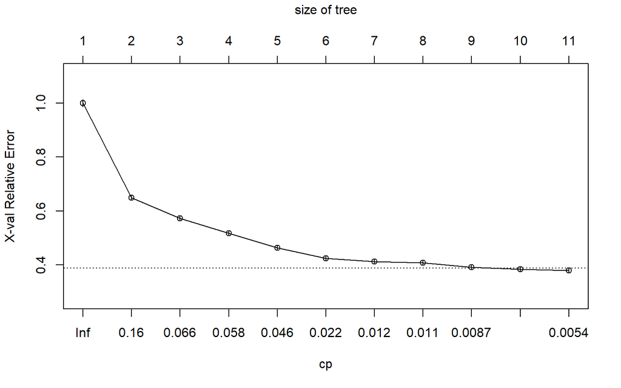

```r
plotcp(fit_dt_reg)
```

```r
# After the cut branches
fit_dt_reg_pruned <- prune(fit_dt_reg,cp =0.024)
print(fit_dt_reg_pruned)
```

```
## n= 21001
##
## node), split, n, deviance, yval
##       * denotes terminal node
##
##  1) root 21001 4.829398e+13  47441.7000
##    2) Loan.Amount.Request< 117340.4 15537 1.076564e+13  30545.7700
##      4) Loan.Amount.Request< 62552.04 8342 1.778629e+12  18546.4100 *
##      5) Loan.Amount.Request>=62552.04 7195 6.393294e+12  44458.0300
##       10) Credit.Score< 650.145 868 2.876174e+10    585.1923 *
##       11) Credit.Score>=650.145 6327 4.464574e+12  50476.9300 *
##    3) Loan.Amount.Request>=117340.4 5464 2.048084e+13  95485.6200
##      6) Credit.Score< 649.995 354 5.202619e+10   1413.2710 *
##      7) Credit.Score>=649.995 5110 1.707903e+13 102002.6000
##       14) Loan.Amount.Request< 200636.9 4022 8.103332e+12  89333.0900 *
##       15) Loan.Amount.Request>=200636.9 1088 5.943545e+12 148837.7000 *
```

```r
# Variable importance value
fit_dt_reg_pruned$variable.importance
```

```
##   Loan.Amount.Request        Property.Price Current.Loan.Expenses
##          2.267336e+13          1.627577e+13          7.581343e+12
##          Credit.Score                Income
##          5.282549e+12          1.006584e+12
```

```r
fit_dt_reg$variable.importance
```

```
##   Loan.Amount.Request        Property.Price Current.Loan.Expenses
##          2.446020e+13          1.717635e+13          7.986404e+12
##          Credit.Score                Income                   Age
##          5.788878e+12          1.077081e+12          4.293850e+09
```

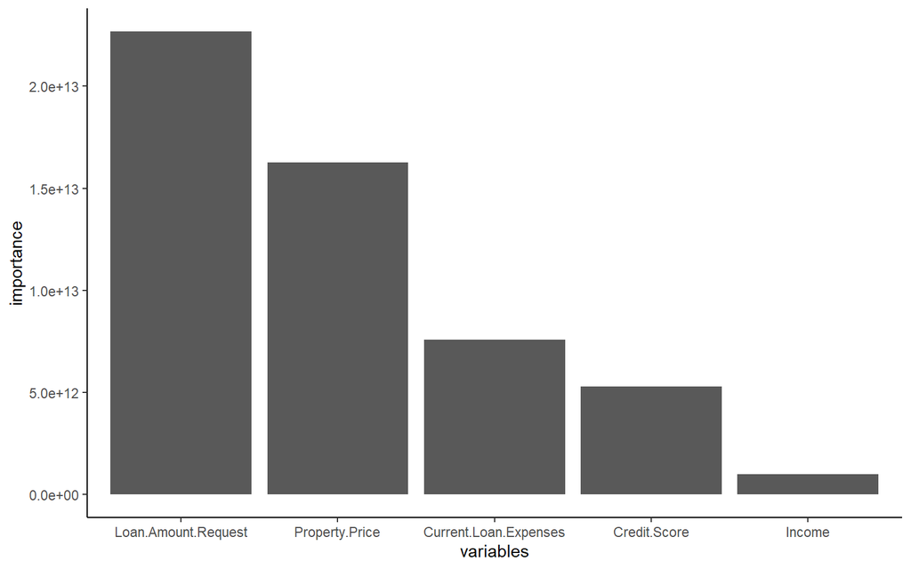

```r
# Variable importance diagram
varimpdata <-
  data.frame(importance=fit_dt_reg_pruned$variable.importance)
ggplot(varimpdata,
       aes(x = as_factor(rownames(varimpdata)),y=importance))+
  geom_col()+
  labs(x = 'variables')+
  theme_classic()
```

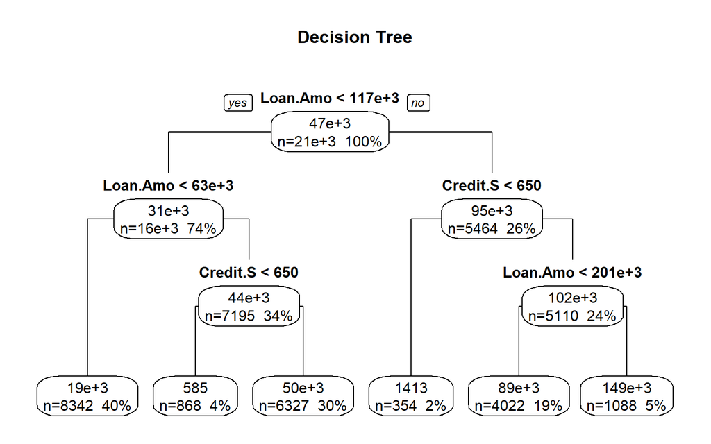

```r
# tree diagram
prp(fit_dt_reg_pruned,
    type=1,
    extra = 101,
    fallen.leaves =TRUE,
    main="Decision Tree")
```

```r
# predicted
# The training set predicts the results
trainpred <- predict(fit_dt_reg_pruned,newdata=train)
```

```r
# Training set prediction error index
defaultSummary(data.frame(obs = train$Loan.Sanction.Amount,pred=trainpred))
```

```
##         RMSE     Rsquared          MAE
## 3.114474e+04 5.781903e-01 2.033239e+04
```

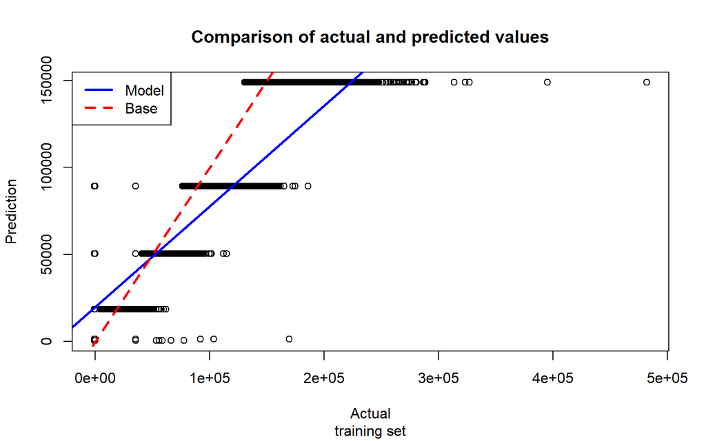

```r
# Graph the training set predicted results
plot(x=train$Loan.Sanction.Amount,
     y=trainpred,
     xlab="Actual",
     ylab="Prediction",
     main='Comparison of actual and predicted values',
     sub= 'training set')
trainlinmod <- lm(trainpred~train$Loan.Sanction.Amount)
abline(trainlinmod,col="blue",lwd = 2.5,lty='solid')
abline(a=0,b=1,col='red',lwd=2.5,lty='dashed')
legend("topleft",
       legend = c("Model","Base"),
       col  = c("blue","red"),
       lwd = 2.5,
       lty = c("solid","dashed"))
```

```r
# Test sets predict results
testpred <- predict(fit_dt_reg_pruned,newdata = test)
```

```r
# Test set prediction error index
defaultSummary(data.frame(obs= test$Loan.Amount.Request,pred=testpred))
```

```
##         RMSE     Rsquared          MAE
## 5.292932e+04 7.441575e-01 4.161299e+04
```

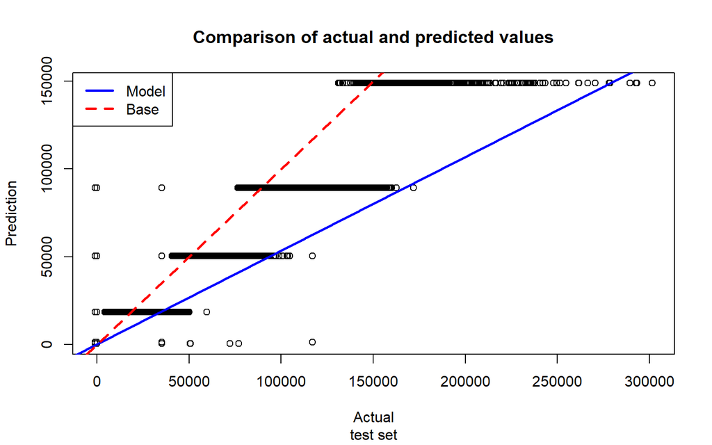

```r
# Graph the test set predicted results
plot(x=test$Loan.Sanction.Amount,
     y=testpred,
     xlab="Actual",
     ylab="Prediction",
     main='Comparison of actual and predicted values',
     sub= 'test set')
testlinmod <- lm(testpred~test$Loan.Amount.Request)
abline(testlinmod,col="blue",lwd = 2.5,lty='solid')
abline(a=0,b=1,col='red',lwd=2.5,lty='dashed')
legend("topleft",
       legend = c("Model","Base"),
       col  = c("blue","red"),
       lwd = 2.5,
       lty = c("solid","dashed"))
```

Conclusion: Loan.Amount.Request and Property.Price have a great influence on the target value. We could see both R2 score are about 0.58 and perform almost the same with the model trained on all features. Thus we could predict the Loan.Sanction.Amount with ridge regression model especially considering a vast amount of data.